# DO: Store XML in a Database

Omi Johnson

2022-11-23

## Question 1

**(20 pts) Create a normalized (BCNF) relational schema and visualize the schema in an ERD (in Crow’s Feet/IE Notation) for the data in the XML file using a tool of your choice such as LucidChart. Include the ERD in your R Notebook.**

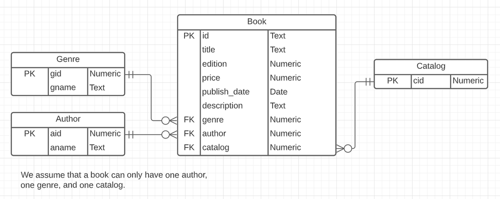

```r
knitr::include_graphics('https://i.imgur.com/nQztzQz.png')
```

## Question 2

**(10 pts) Create a SQLite database that implements the schema, i.e., define the tables with CREATE TABLE. Use SQL chunks in your R Notebook.**

```r
library(RSQLite)

db <- dbConnect(SQLite(), "booksDB.db")
```

```sql
DROP TABLE IF EXISTS Book;
```

```sql
DROP TABLE IF EXISTS Author;
```

```sql
DROP TABLE IF EXISTS Catalog;
```

```sql
DROP TABLE IF EXISTS Genre;
```

```sql
CREATE TABLE Catalog(
  cid Integer NOT NULL PRIMARY KEY
)
```

```sql
CREATE TABLE Author(
  aid Integer NOT NULL PRIMARY KEY,
  aname Text NOT NULL
)
```

```sql
CREATE TABLE Genre(
  gid Integer NOT NULL PRIMARY KEY,
  gname Text NOT NULL
)
```

```sql
CREATE TABLE Book(
  id Text NOT NULL PRIMARY KEY,
  title Text NOT NULL,
  edition Numeric,
  price Numeric NOT NULL,
  publish_date Date NOT NULL,
  description Text NOT NULL,
  genre Numeric NOT NULL REFERENCES Genre(gid),
  author Numeric NOT NULL REFERENCES Author(aid),
  catalog Numeric NOT NULL REFERENCES Catalog(cid)
)
```

## Question 3

**(30 pts) Load the XML data from the file into R data frames; you will need to use either node-by-node traversal of the XML tree or a combination of node-by-node traversal with XPath; you likely will not be able to accomplish it with only XPath. Use surrogate keys and/or the ID attributes in the XML to establish relationships.**

```r
library(XML)
library(stringr)

xml <- xmlParse("Books-v3.xml")

xpath_help <- function(...) {
  xpathSApply(xml, paste0(...))
}
```

```r
# create genre table
genres <- xpath_help("//book/genre/text()") |>
  sapply(function(g) as(g, "character")) |>
  unique()

genres_df <- data.frame(gid = 1:length(genres),
                        gname = genres)

head(genres_df)
```

```
##   gid           gname
## 1   1        Computer
## 2   2         Fantasy
## 3   3         Romance
## 4   4          Horror
## 5   5 Science Fiction
```

```r
# create author table
authors <- xpath_help("//book/author/text()") |>
  sapply(function(a) as(a, "character")) |>
  unique()

authors_df <- data.frame(aid = 1:length(authors),
                         aname = authors)

head(authors_df)
```

```
##   aid                aname
## 1   1 Gambardella, Matthew
## 2   2           Ralls, Kim
## 3   3          Corets, Eva
## 4   4     Randall, Cynthia
## 5   5          Galos, Mike
## 6   6       Thurman, Paula
```

```r
# create catalog tables
catalogs <- xpath_help("//catalog")

catalogs_df <- data.frame(cid = 1:length(catalogs))

head(catalogs_df)
```

```
##   cid
## 1   1
```

```r
# helper function that creates a list for a book entry
processBook <- function(book, cid) {
  # helper method to extract text for an element
  book_elem <- function(elem, type = "character") {
    xpathSApply(book, paste0(elem, "/text()"))[[1]] |> as(type)
  }

  # mandatory elements
  id <- xpathSApply(book, "@id")
  title <- book_elem("title")
  price <- book_elem("price", type = "numeric")
  publish_date <- book_elem("publish_date")
  description <- book_elem("description")

  # optional elements
  edition <- book_elem("edition", type = "numeric")
  if (length(edition) == 0) {edition <- NA}

  # references
  genre <- which(genres == book_elem("genre"))
  author <- which(authors == book_elem("author"))
  catalog <- cid

  list("id" = id, 'title' = title, 'edition' = edition, 'price' = price,
       'publish_date' = publish_date, 'description' = description,
       'genre' = genre, 'author' = author, 'catalog' = catalog)
}

# defining books base
books_df <- data.frame (id = character(0),
                       title = character(0),
                       edition = numeric(0),
                       price = numeric(0),
                       publish_date = character(0),
                       description = character(0),
                       genre = numeric(0),
                       author = numeric(0),
                       catalog = numeric(0),
                       stringsAsFactors = F)

# iterating through catalogs and by extension, books to create table
for (cid in catalogs_df$cid) {
  catalog <- catalogs[[cid]]

  books <- xpathSApply(catalog, "book")

  books_df <- do.call(rbind.data.frame,
                      lapply(books, processBook, cid)) |>
    rbind(books_df)
}

head(books_df)
```

```
##      id                 title edition price publish_date
## 1 bk101 XML Developer's Guide      NA 44.95   2000-10-01
## 2 bk102         Midnight Rain      NA  5.95   2000-12-16
## 3 bk103       Maeve Ascendant      NA  5.95   2000-11-17
## 4 bk104       Oberon's Legacy      NA  5.95   2001-03-10
## 5 bk105    The Sundered Grail      NA  5.95   2001-09-10
## 6 bk106           Lover Birds      NA  4.95   2000-09-02
##                                                                                                                                                                          description
## 1                                                                                                                        An in-depth look at creating applications \n      with XML.
## 2                                               A former architect battles corporate zombies, \n      an evil sorceress, and her own childhood to become queen \n      of the world.
## 3                                               After the collapse of a nanotechnology \n      society in England, the young survivors lay the \n      foundation for a new society.
## 4 In post-apocalypse England, the mysterious \n      agent known only as Oberon helps to create a new life \n      for the inhabitants of London. Sequel to Maeve \n      Ascendant.
## 5                                                    The two daughters of Maeve, half-sisters, \n      battle one another for control of England. Sequel to \n      Oberon's Legacy.
## 6                                                                                   When Carla meets Paul at an ornithology \n      conference, tempers fly as feathers get ruffled.
##   genre author catalog
## 1     1      1       1
## 2     2      2       1
## 3     2      3       1
## 4     2      3       1
## 5     2      3       1
## 6     3      4       1
```

## Question 4

**(20 pts) Transform data types as necessary and then save the data frames to the appropriate tables in the database using a strategy of your choice (e.g., dbWriteTable()).**

```r
dbWriteTable(db, "Author", authors_df, overwrite = TRUE)
dbWriteTable(db, "Genre", genres_df, overwrite = TRUE)
dbWriteTable(db, "Catalog", catalogs_df, overwrite = TRUE)
dbWriteTable(db, "Book", books_df, overwrite = TRUE)
```

## Question 5

**(20 pts) Once the data from the XML is in the database, build SQL chunks for the following queries against the SQLite database:**

What is the number of genres have at least three books?

```sql
SELECT COUNT(*)
  FROM (SELECT genre
          FROM Book
         GROUP BY genre
        HAVING COUNT(*) >= 3)
```

1 records

| COUNT(*) |
| --- |
| 2 |

What is the oldest year in which a publication was published?

```sql
SELECT MIN(strftime('%Y', publish_date)) as "Year"
  FROM Book
```

1 records

| Year |
| --- |
| 2000 |

Find the number of books and average price for each genre.

```sql
SELECT genre, COUNT(*) AS numBooks, AVG(price) AS avgPrice
  FROM Book
 GROUP BY genre
```

5 records

| genre | numBooks | avgPrice |
| --- | --- | --- |
| 1 | 7 | 43.39286 |
| 2 | 5 | 6.35000 |
| 3 | 2 | 4.95000 |
| 4 | 1 | 4.95000 |
| 5 | 1 | 6.95000 |

```sql
SELECT b.price AS Price, a.aname AS Author
  FROM Book b INNER JOIN Author a ON (b.author = a.aid)
 WHERE b.price/(SELECT AVG(price) FROM Book) NOT BETWEEN .8 AND 1.2
```

Displaying records 1 - 10

| Price | Author |
| --- | --- |
| 44.95 | Gambardella, Matthew |
| 5.95 | Ralls, Kim |
| 5.95 | Corets, Eva |
| 5.95 | Corets, Eva |
| 5.95 | Corets, Eva |
| 4.95 | Randall, Cynthia |
| 69.95 | Galos, Mike |
| 4.95 | Thurman, Paula |
| 4.95 | Knorr, Stefan |
| 6.95 | Kress, Peter |